# Statistical Comparison of Treatment Assignment Designs

Formal Hypothesis Testing for Design Selection in Spatial CRTs

Author

Andrew Walther

Published

September 24, 2026

# 1 Introduction

This report presents formal statistical hypothesis tests to compare the performance of 8 treatment assignment designs evaluated in the IncidenceDesign simulation study for Spatial Cluster Randomized Trials (CRTs). While prior analyses have characterized design performance descriptively using mean MSE, coverage probability, and win-rate rankings, these comparisons lack the statistical rigor needed to declare one design significantly better than another.

The central question is: **can we provide statistical evidence that certain designs yield significantly better estimation accuracy (lower MSE for $\hat{\tau}$) than others?** Answering this question is essential for providing actionable guidance to investigators planning future spatial CRTs.

At the primary effect size ($\tau = 1.0$) the simulation has 2560 scenarios: 160 unique parameter combinations per neighbor type, each tested under all 8 designs, for both queen and rook contiguity. Queen contiguity is the primary analysis and rook is a sensitivity analysis; the two are tested separately and never pooled for a headline result. This paired structure is exploited by the non-parametric tests described below.

# 2 Methods

## 2.1 Overview of the Comparison Problem

We seek to determine whether the 8 treatment assignment designs differ *significantly* in their ability to estimate the treatment effect $\tau$, as measured by MSE. This is fundamentally a **multiple treatment comparison** problem: we have $k = 8$ designs, each observed under the same set of experimental conditions (parameter combinations), and we wish to test whether any design is systematically better or worse.

Because the same data-generating conditions are shared across all designs within each parameter combination, we have a **paired / blocked** experimental structure. Standard parametric tests (e.g., repeated-measures ANOVA) assume normally distributed residuals, which may not hold for MSE values. We therefore use **non-parametric rank-based tests** that make no distributional assumptions.

The total number of unique pairwise comparisons among $k = 8$ designs is:
$$\binom{k}{2} = \binom{8}{2} = 28$$

## 2.2 Blocking Structure

Each scenario is defined by a unique combination of simulation parameters:

| Parameter | Levels | Count |
| --- | --- | --- |
| Incidence Mode | iid, spatial, poisson (with $\rho_X \in \{0.20, 0.50\}$) | 5 configs |
| $\rho$ (outcome spatial autocorrelation) | 0.00, 0.01, 0.20, 0.50 | 4 |
| $\gamma$ (spillover magnitude) | 0.50, 0.60, 0.70, 0.80 | 4 |
| Spillover Type | control-only, bidirectional | 2 |

This produces $5 \times 4 \times 4 \times 2 = 160$ **blocks** per neighbor type. Neighbor type (queen, rook) is not a blocking factor: each test is run separately on the 160 queen blocks (primary) and the 160 rook blocks (sensitivity). Within each block, all 8 designs were evaluated under identical data-generating conditions, creating a natural repeated-measures / paired design. The metric of interest is the **Mean Squared Error (MSE)** of the MLE estimator $\hat{\tau}$ for the primary scenario $\tau = 1.0$. The tau-sweep sensitivity analysis ($\tau \in \{0.8, 1.0, 1.5, 2.0, 3.0\}$) is presented in Section 6.

Each design’s MSE per block is aggregated from 250 model fits: 10 incidence surfaces $X_k$ $\times$ 25 design draws per surface, each fit with its own noise draw (Checkerboard, the only deterministic design, uses the same assignment in every fit). Designs are drawn from the same surface $X_k$ that enters the outcome and the analysis model. Designs within a block share the noise draws and the surfaces, which is what makes the within-block comparison paired.

## 2.3 Friedman Test (Omnibus)

The **Friedman test** (Friedman, 1937) is a non-parametric alternative to one-way repeated-measures ANOVA. It is the standard method for comparing multiple treatments or methods measured under matched conditions.

**Procedure:** Within each of the $N = 160$ blocks, the $k = 8$ designs are ranked by MSE (rank 1 = lowest MSE = best performance). The test then evaluates whether the average ranks differ across designs more than expected by chance.

**Hypotheses:**

- $H_0$: All $k$ designs have equal average MSE ranks across the $N$ blocks. No design is systematically better or worse.
- $H_1$: At least one design’s average rank differs from the others.

The Friedman test statistic is:
$$Q = \frac{12N}{k(k+1)} \left[\sum_{j=1}^{k} \bar{R}_j^2 - \frac{k(k+1)^2}{4}\right]$$

where $\bar{R}_j$ is the average rank of design $j$ across all blocks. Under $H_0$, $Q$ follows a $\chi^2$ distribution with $k - 1 = 7$ degrees of freedom.

> **Reference:** Friedman, M. (1937). The use of ranks to avoid the assumption of normality implicit in the analysis of variance. *Journal of the American Statistical Association*, 32(200), 675-701.

## 2.4 Nemenyi Post-hoc Test

When the Friedman test rejects $H_0$ (indicating at least one design differs), we need post-hoc pairwise comparisons to identify *which* designs differ. The **Nemenyi test** (Nemenyi, 1963) is the non-parametric analogue of the Tukey HSD test and controls the **family-wise error rate** across all $\binom{k}{2} = 28$ simultaneous comparisons.

Two designs $i$ and $j$ are declared significantly different at level $\alpha$ if and only if their average rank difference $|\bar{R}_i - \bar{R}_j|$ exceeds the **Critical Difference (CD)**:

$$CD = \frac{q_{\alpha, k, \infty}}{\sqrt{2}} \times \sqrt{\frac{k(k+1)}{6N}}$$

where $q_{\alpha, k, \infty}$ is the critical value of the Studentized range distribution with $k$ groups and infinite degrees of freedom, $k = 8$, and $N = 160$ blocks.

Results are presented as a **Critical Difference (CD) diagram** (introduced to the machine learning community by Demšar, 2006). In this diagram:

- Designs are placed on a horizontal number line by their **average rank** (lower = better MSE).
- Thick horizontal bars connect groups of designs that are **NOT** significantly different from each other — these form **equivalence groups**.
- If two designs are *not* connected by a shared bar, their performance difference *is* statistically significant.
- A red arrow at the bottom shows the CD scale for reference.

> **References:**
> - Nemenyi, P.B. (1963). *Distribution-free multiple comparisons*. Ph.D. dissertation, Princeton University.
> - Demšar, J. (2006). Statistical comparisons of classifiers over multiple data sets. *Journal of Machine Learning Research*, 7, 1-30.

## 2.5 Pairwise Wilcoxon Signed-Rank Tests

As a **sensitivity analysis** and to provide a more widely-known test alongside the Friedman/Nemenyi framework, we also perform pairwise **Wilcoxon signed-rank tests** (Wilcoxon, 1945) on the paired MSE values.

**Hypotheses (for each pair of designs $i, j$):**

- $H_0$: The distribution of paired MSE differences $(\text{MSE}_i - \text{MSE}_j)$ is symmetric about zero. That is, designs $i$ and $j$ have equivalent MSE performance.
- $H_1$: The distribution is not symmetric about zero. One design systematically outperforms the other.

This yields 28 individual tests. To control the **family-wise error rate** across all tests, p-values are adjusted using the **Holm step-down procedure** (Holm, 1979), which is uniformly more powerful than Bonferroni correction while still controlling the Type I error rate.

> **References:**
> - Wilcoxon, F. (1945). Individual comparisons by ranking methods. *Biometrics Bulletin*, 1(6), 80-83.
> - Holm, S. (1979). A simple sequentially rejective multiple test procedure. *Scandinavian Journal of Statistics*, 6(2), 65-70.

## 2.6 Significance Notation

Throughout this report, statistical significance is indicated using the following star notation:

| Symbol | Meaning | Interpretation |
| --- | --- | --- |
| `***` | $p < 0.001$ | Very strong evidence against $H_0$ |
| `**` | $p < 0.01$ | Strong evidence against $H_0$ |
| `*` | $p < 0.05$ | Moderate evidence against $H_0$ |
| `ns` | $p \geq 0.05$ | Insufficient evidence to reject $H_0$ |

# 3 Results: Aggregate Analysis

All results in this section, except Section 3.6, are for **queen contiguity** (the primary analysis) at $\tau = 1.0$. The rook sensitivity analysis is reported separately in Section 3.6.

## 3.1 Friedman Omnibus Test

Friedman omnibus test result (queen, tau = 1.0).

| Statistic | df | P-value | N Blocks | Decision |
| --- | --- | --- | --- | --- |
| 711.29 | 7 | <2e-16 | 160 | Reject H0 |

The Friedman test yields $\chi^2 = 711.29$ with $7$ degrees of freedom ($p < 2.2 \times 10^{-16}$). We **reject the null hypothesis**: there is overwhelming evidence that the 8 designs differ in their MSE performance.

## 3.2 Average Ranks

Designs ordered by average MSE rank across the queen blocks (1 = best).

| Design | Average Rank | Rank Position |
| --- | --- | --- |
| Design 3 | 2.100 | 1 |
| Design 8 | 2.350 | 2 |
| Design 7 | 3.312 | 3 |
| Design 6 | 3.356 | 4 |
| Design 4 | 5.138 | 5 |
| Design 5 | 6.244 | 6 |
| Design 1 | 6.737 | 7 |
| Design 2 | 6.763 | 8 |

Saturation Quadrants and Incidence-Guided Saturation Quadrants occupy the top two positions with nearly identical average ranks (2.100 and 2.350), while High Incidence Focus ranks last at 6.763, just behind Checkerboard (6.737).

## 3.3 Critical Difference Diagram

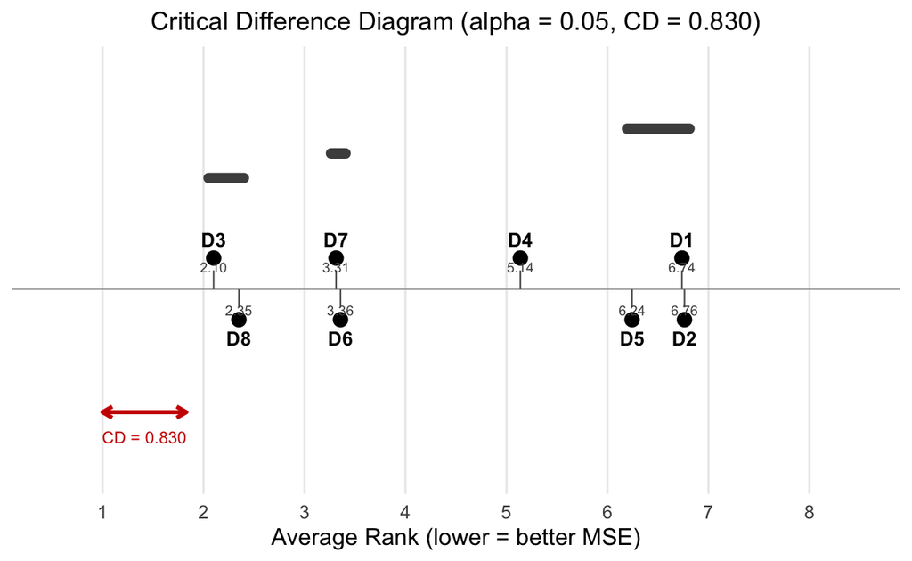

Critical Difference diagram (queen, tau = 1.0). Designs are placed by average MSE rank (lower = better). Horizontal bars connect designs that are NOT significantly different at the 0.05 level. The red arrow shows the critical difference scale.

**How to read this diagram:** Each design is positioned on the number line by its average rank across all 160 queen blocks (lower = better). The thick dark bars above the axis connect designs that are **statistically equivalent** — i.e., their pairwise Nemenyi p-value is $\geq 0.05$. Designs that do *not* share a bar are significantly different from each other.

The red double-arrow labeled “CD” at the bottom shows the **Critical Difference** threshold: if two designs are separated by more than this distance on the rank axis, their difference is statistically significant.

The CD diagram reveals **3 equivalence group(s)**:

- **Group 1**: Design 3, Design 8 (avg ranks 2.10 – 2.35)
- **Group 2**: Design 7, Design 6 (avg ranks 3.31 – 3.36)
- **Group 3**: Design 5, Design 1, Design 2 (avg ranks 6.24 – 6.76)

The Nemenyi critical difference is **CD = 0.830** at $\alpha = 0.05$. Designs whose average rank difference exceeds 0.830 are declared significantly different.

## 3.4 Pairwise Wilcoxon Results

Of the 28 pairwise comparisons, **26 are statistically significant** (Holm-adjusted $p < 0.05$) and 2 are not.

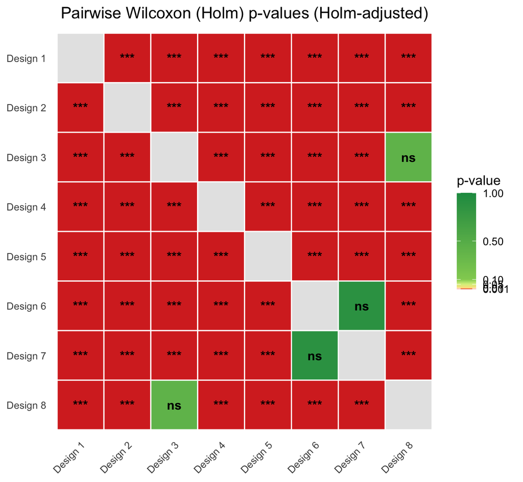

Pairwise Wilcoxon signed-rank p-values (queen, tau = 1.0; Holm-adjusted). Stars indicate significance: *** p < 0.001, ** p < 0.01, * p < 0.05, ns = not significant.

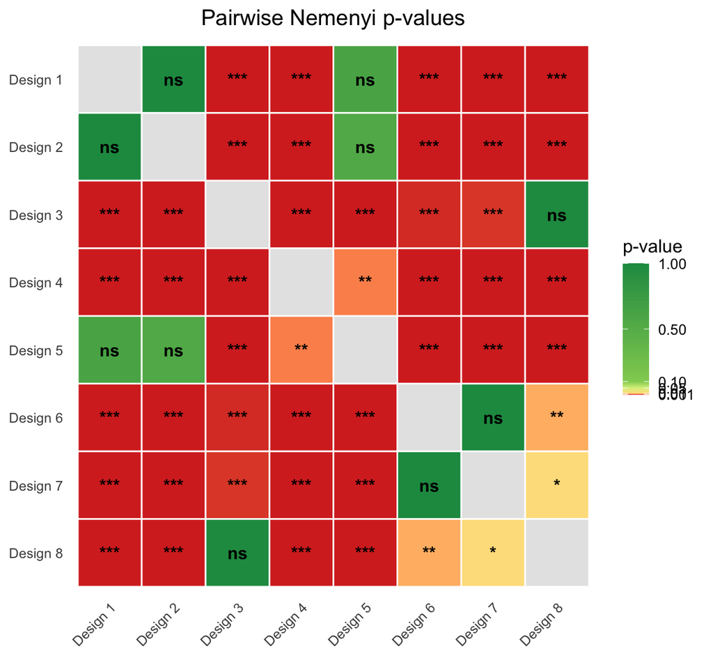

Pairwise Nemenyi post-hoc p-values from the Friedman test (queen, tau = 1.0).

The non-significant pairs (Wilcoxon) identify designs whose MSE performance is statistically indistinguishable:

Design pairs with no significant MSE difference (Wilcoxon; queen, tau = 1.0).

| Design A | Design B | Wilcoxon p | Nemenyi p |
| --- | --- | --- | --- |
| Design 3 | Design 8 | 0.4130 | 0.9849 |
| Design 6 | Design 7 | 0.8842 | 1.0000 |

## 3.5 MSE Distribution with Significance

The following boxplot shows the full distribution of scenario-level MSE values for each design under queen contiguity, ordered by median MSE (best on the left). Brackets above the boxes with significance stars indicate pairwise comparisons from the Wilcoxon signed-rank test (Holm-adjusted). To avoid visual clutter, up to 8 key comparisons are shown, prioritizing those involving the best- and worst-performing designs.

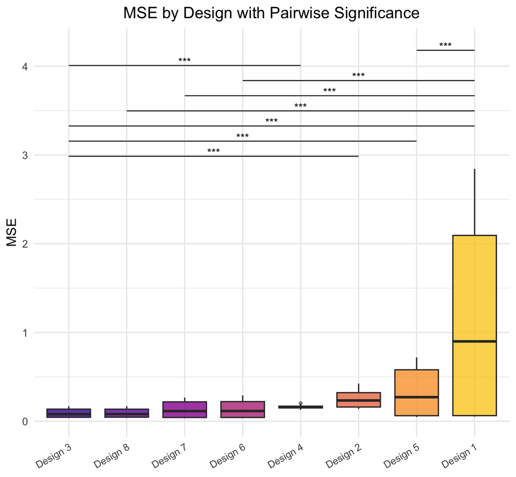

Boxplot of MSE by design (queen, tau = 1.0; ordered by median MSE). Brackets with significance stars show Wilcoxon signed-rank test results (Holm-adjusted). Stars: *** p < 0.001, ** p < 0.01, * p < 0.05.

## 3.6 Rook Contiguity (Sensitivity)

The same Friedman, Nemenyi and Wilcoxon tests, run on the 160 rook blocks at $\tau = 1.0$. Under rook contiguity the Checkerboard design’s treatment effect is **not identified**: every treated cell’s rook neighbours are all controls and vice versa, so $WZ = 1 - Z$, the oracle model drops the spillover term, and the Checkerboard estimate absorbs the spillover (bias $\approx -\gamma$, coverage 0.15). Its estimates are kept but flagged; its last-place rank under rook reflects this non-identification rather than a design-performance comparison.

Friedman omnibus test result (rook, tau = 1.0; sensitivity).

| Statistic | df | P-value | N Blocks | Decision |
| --- | --- | --- | --- | --- |
| 900.22 | 7 | <2e-16 | 160 | Reject H0 |

Designs ordered by average MSE rank across the rook blocks (1 = best). Design 1 (Checkerboard) is not identified under rook.

| Design | Average Rank | Rank Position |
| --- | --- | --- |
| Design 3 | 2.281 | 1 |
| Design 8 | 2.306 | 2 |
| Design 6 | 2.919 | 3 |
| Design 7 | 3.038 | 4 |
| Design 4 | 5.225 | 5 |
| Design 5 | 5.275 | 6 |
| Design 2 | 6.969 | 7 |
| Design 1 | 7.987 | 8 |

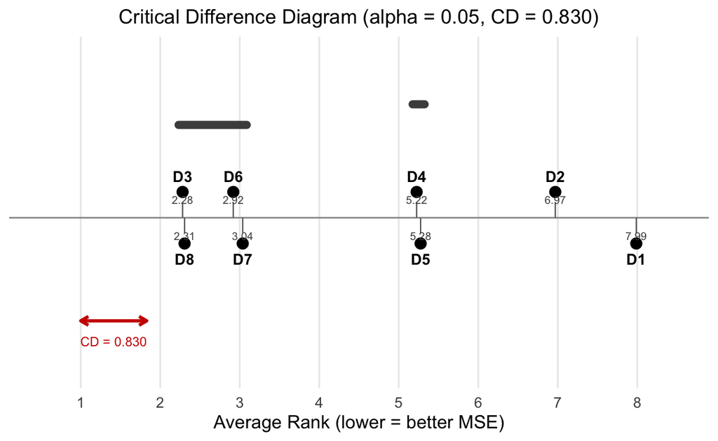

Critical Difference diagram (rook, tau = 1.0; sensitivity). Design 1 (Checkerboard) is not identified under rook.

Under rook the Nemenyi critical difference is CD = 0.830, and the CD diagram shows 2 equivalence group(s):

- **Group 1**: Design 3, Design 8, Design 6, Design 7 (avg ranks 2.28 – 3.04)
- **Group 2**: Design 4, Design 5 (avg ranks 5.22 – 5.28)

21 of 28 pairs differ significantly under Nemenyi and 25 of 28 under the Holm-adjusted Wilcoxon test.

# 4 Results: Conditional Analysis

To assess whether design rankings are **robust** across simulation conditions, we repeat the Friedman test within strata defined by individual parameters. All strata are **within queen contiguity** (the primary analysis), except the neighbor-type strata, which compare queen and rook directly. If the Friedman test remains significant within every stratum and the best-ranked designs are consistent, the recommendation is robust.

## 4.1 Summary of Conditional Friedman Tests

Friedman test results within each parameter stratum (queen, except the neighbor-type strata). 'Best Group' lists designs in the top equivalence group (statistically indistinguishable from the best).

| Parameter | Stratum | Chi-squared | P-value | N Blocks | Best Group | Significant |
| --- | --- | --- | --- | --- | --- | --- |
| Rho | Rho = 0 | 179.47 | < 2.2e-16 | 40 | D3, D8, D6, D7 | Yes |
| Rho | Rho = 0.01 | 181.02 | < 2.2e-16 | 40 | D8, D3, D6, D7 | Yes |
| Rho | Rho = 0.2 | 181.43 | < 2.2e-16 | 40 | D3, D8, D7 | Yes |
| Rho | Rho = 0.5 | 172.32 | < 2.2e-16 | 40 | D3, D8, D6, D7 | Yes |
| Gamma | Gamma = 0.5 | 174.33 | < 2.2e-16 | 40 | D3, D8, D6, D7 | Yes |
| Gamma | Gamma = 0.6 | 180.52 | < 2.2e-16 | 40 | D3, D8, D7, D6 | Yes |
| Gamma | Gamma = 0.7 | 177.52 | < 2.2e-16 | 40 | D3, D8, D6, D7 | Yes |
| Gamma | Gamma = 0.8 | 180.09 | < 2.2e-16 | 40 | D8, D3, D6, D7 | Yes |
| Spillover_Type | Spillover_Type = both | 485.14 | < 2.2e-16 | 80 | D7, D6, D3, D8 | Yes |
| Spillover_Type | Spillover_Type = control_only | 539.48 | < 2.2e-16 | 80 | D8, D3 | Yes |
| Neighbor_Type | Neighbor_Type = queen | 711.29 | < 2.2e-16 | 160 | D3, D8 | Yes |
| Neighbor_Type | Neighbor_Type = rook | 900.22 | < 2.2e-16 | 160 | D3, D8, D6, D7 | Yes |
| Incidence_Mode | Incidence_Mode = iid | 140.74 | < 2.2e-16 | 32 | D3, D8, D7, D6 | Yes |
| Incidence_Mode | Incidence_Mode = poisson | 284.22 | < 2.2e-16 | 64 | D3, D8, D7, D6 | Yes |
| Incidence_Mode | Incidence_Mode = spatial | 286.79 | < 2.2e-16 | 64 | D3, D8, D6, D7 | Yes |
| True_Tau | True_Tau = 0.8 | 721.71 | < 2.2e-16 | 160 | D3, D8 | Yes |
| True_Tau | True_Tau = 1 | 711.29 | < 2.2e-16 | 160 | D3, D8 | Yes |
| True_Tau | True_Tau = 1.5 | 680.24 | < 2.2e-16 | 160 | D3, D8 | Yes |
| True_Tau | True_Tau = 2 | 652.86 | < 2.2e-16 | 160 | D3, D8 | Yes |
| True_Tau | True_Tau = 3 | 611.43 | < 2.2e-16 | 160 | D3, D8, D6 | Yes |

The Friedman test is **significant in every stratum** (largest p-value 3.6e-27), indicating that design differences are not an artifact of any particular parameter setting. The strata are not independent replications: blocks within an incidence configuration share the same incidence surfaces, and the $\tau$ strata share treatment and noise draws (see Section 6).

## 4.2 Conditional CD Diagrams

The following CD diagrams show how design rankings shift (or remain stable) across levels of key simulation parameters.

### 4.2.1 By Outcome Spatial Autocorrelation ($\rho$)

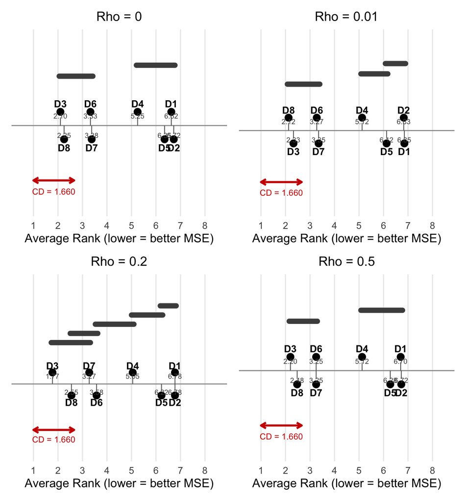

CD diagrams stratified by outcome spatial autocorrelation (Rho; queen). Each panel shows one stratum.

### 4.2.2 By Spillover Magnitude ($\gamma$)

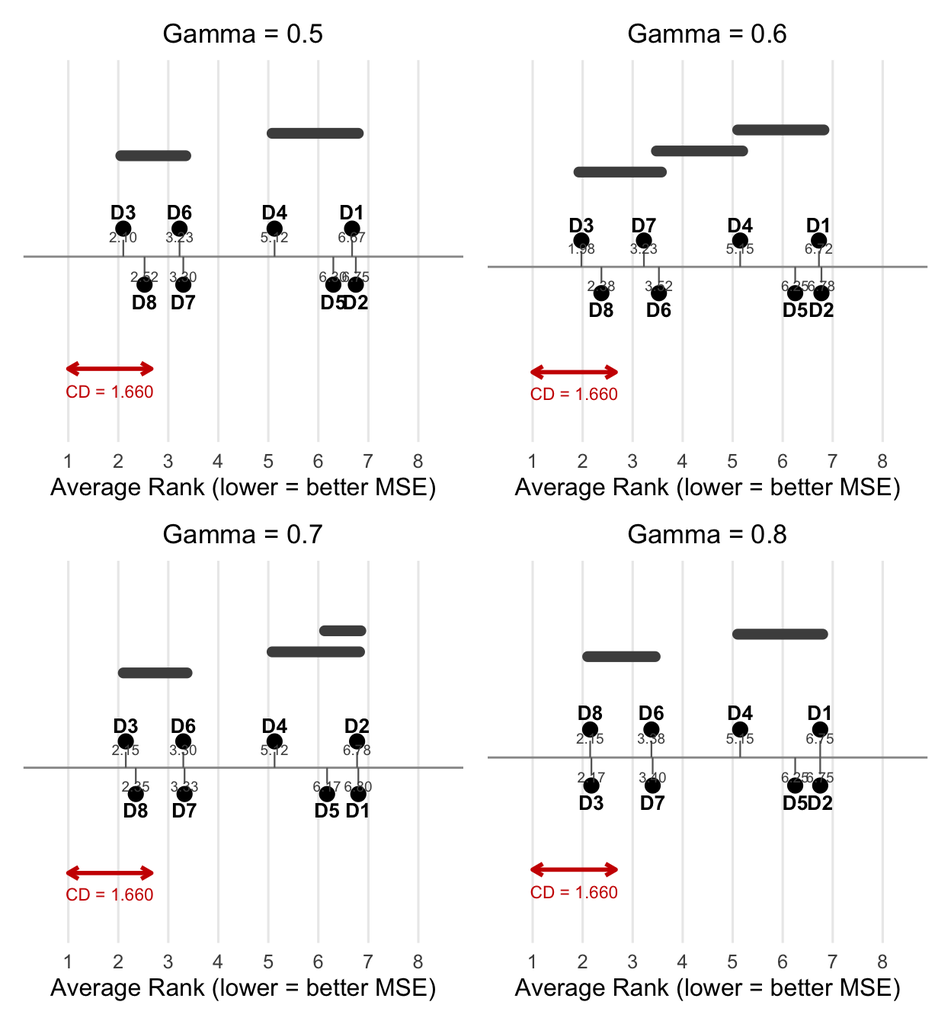

CD diagrams stratified by spillover magnitude (Gamma; queen). Each panel shows one stratum.

### 4.2.3 By Spillover Type

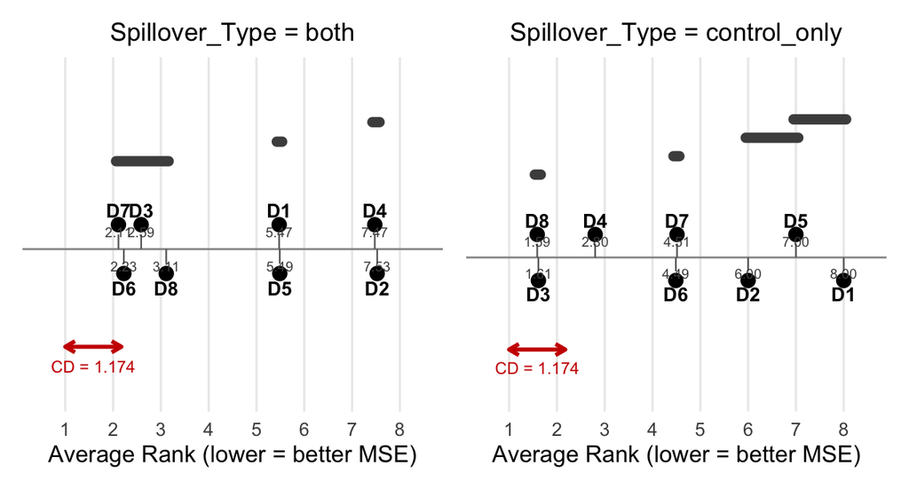

CD diagrams stratified by spillover type (queen).

### 4.2.4 By Neighbor Type

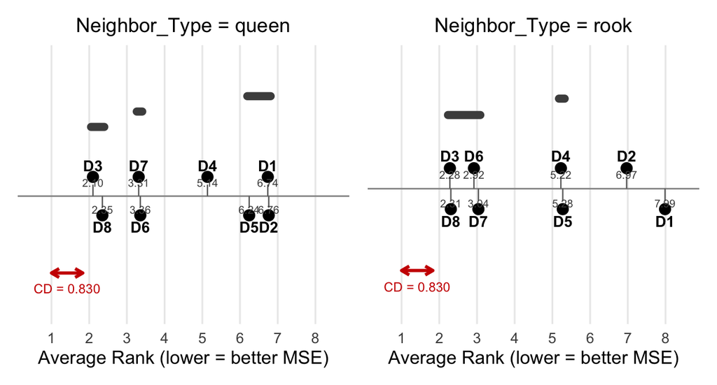

CD diagrams stratified by neighbor type (tau = 1.0). Under rook, Design 1 (Checkerboard) is not identified (WZ = 1 - Z); its estimates are kept but flagged.

### 4.2.5 By Incidence Mode

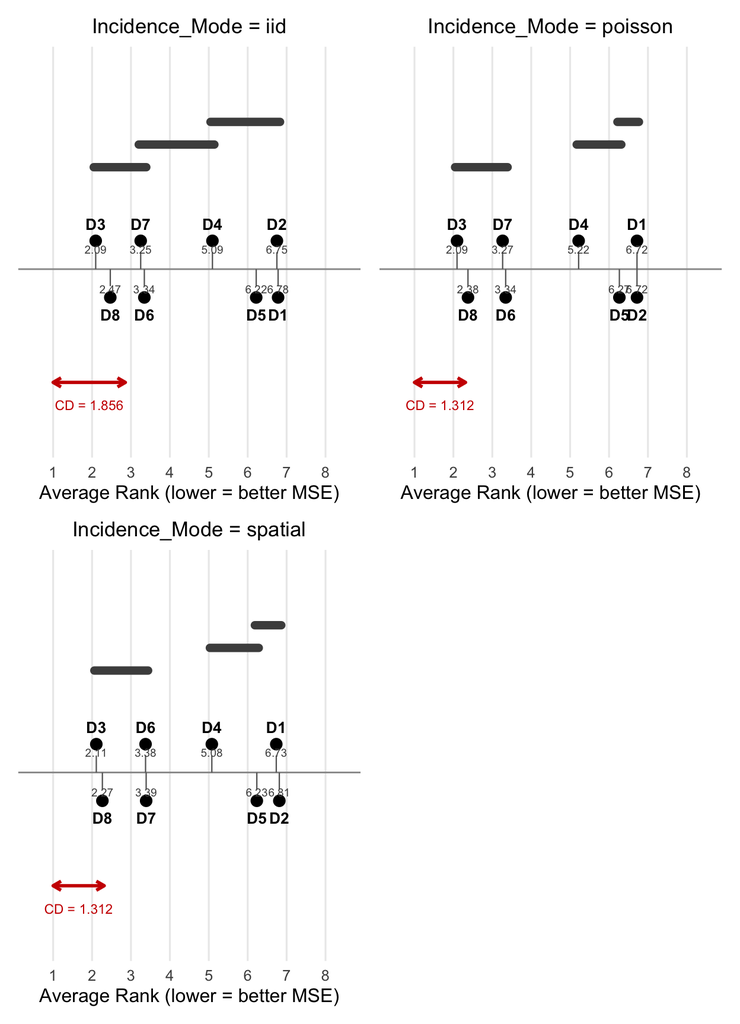

CD diagrams stratified by incidence generation mode (queen). Each panel shows one stratum.

# 5 Discussion

## 5.1 Key Findings

1. **Overwhelming evidence of design differences.** The Friedman test ($\chi^2 = 711.29$, $p < 2.2 \times 10^{-16}$) decisively rejects the null hypothesis that all designs perform equally. Under queen contiguity, the average rank gap between the best (Saturation Quadrants, rank 2.10) and worst (High Incidence Focus, rank 6.76) design is 4.66 on a 8-point scale. The rook sensitivity analysis also rejects ($\chi^2 = 900.22$; Section 3.6).
2. **Saturation Quadrants and Incidence-Guided Saturation Quadrants are the top performers.** These two designs are statistically indistinguishable from each other (Nemenyi $p > 0.05$) and form the top equivalence group in the queen CD diagram (Nemenyi $p = 0.9849$, Wilcoxon Holm-adjusted $p = 0.413$). Both employ quadrant-based saturation strategies; one draws each quadrant’s saturation at random and the other orders the saturations by quadrant incidence, and the tests do not distinguish them.
3. **Checkerboard has by far the largest MSE, but it shares the bottom rank group.** Under queen, Checkerboard’s mean MSE is 1.087 against 0.090 for Saturation Quadrants; it is essentially unbiased (mean bias 0.001), so the MSE is almost entirely variance (mean SD 0.851). By average rank it sits beside High Incidence Focus and 2x2 Blocking, from which the Nemenyi test does not separate it; the Holm-adjusted Wilcoxon test separates it from every other design. Under rook, Checkerboard ranks last, but there its treatment effect is not identified ($WZ = 1 - Z$), so that rank is a flagged non-identification, not a design comparison.
4. **Rankings are robust across all simulation parameters.** The Friedman test is significant within every stratum tested (all $p < 2.2 \times 10^{-16}$), and the two saturation quadrant designs are in the top equivalence group in every stratum, regardless of the level of spatial autocorrelation, spillover magnitude, spillover type, neighbor contiguity, or incidence generation mode. In many strata Balanced Quartiles and Balanced Halves join that top group. The strata share incidence surfaces (and, for $\tau$, treatment and noise draws), so they are not independent confirmations.

## 5.2 Implications for Study Design

For investigators planning a spatial CRT with spatially heterogeneous outcomes, these results provide strong statistical evidence to recommend **saturation quadrant designs** (Saturation Quadrants or Incidence-Guided Saturation Quadrants) over alternative strategies. The recommendation is not sensitive to specific assumptions about the data-generating process within the range of parameters explored.

In particular:

- **Avoid the Checkerboard design** — under queen it has the largest mean MSE of any design (1.087, nearly all variance), and under rook its treatment effect is not identified.
- **Saturation quadrant designs** leverage spatial structure by assigning different treatment saturation levels to different regions, which provides better identification of the treatment effect under spatial dependence.
- The two saturation quadrant designs are statistically indistinguishable; the choice between random and incidence-ordered saturation does not change estimation accuracy in these simulations.

## 5.3 Limitations

- **Primary $\tau = 1.0$**: Omnibus and pairwise tests condition on the primary effect size. Sensitivity across $\tau \in \{0.8, 1.0, 1.5, 2.0, 3.0\}$ is presented in Section 6; rankings remain stable across effect sizes, although the $\tau$ levels share treatment and noise draws and so are not independent confirmations.
- **Blocks are not fully independent**: blocks within an incidence configuration share the same 10 incidence surfaces, so a Friedman test over blocks overstates the information about surface-to-surface variation.
- **Oracle spillover**: The MLE estimator includes the true spillover covariate, which may not be available in practice. A non-oracle sensitivity estimator ($Y \sim Z + X$) was also run but is not analysed in this report.
- **Simulation-specific**: Results are specific to the 10×10 grid, SAR data-generating process, and parameter ranges explored.

# 6 Tau Sensitivity Analysis

The tau-sweep simulation (12,800 scenarios) swept $\tau \in \{0.8, 1.0, 1.5, 2.0, 3.0\}$. The primary question is whether the design ranking established at $\tau = 1.0$ is robust to the effect size assumption. All results in this section are for queen contiguity.

The per-$\tau$ Friedman tests use common random numbers: every $\tau$ level reuses the same treatment assignments and noise draws, and only $\tau$ changes. They are therefore **not independent confirmations** of one another; agreement across $\tau$ shows that the ranking is insensitive to the effect size, not that it has been replicated five times.

## 6.1 Conditional Tests by True Tau Level

Conditional Friedman test results stratified by true tau level (queen). All p-values are below 2.2e-16. The tau levels share treatment and noise draws, so these are not independent tests.

| Stratum | Chi_squared | P_value | N_blocks | Best_Group |
| --- | --- | --- | --- | --- |
| True_Tau = 0.8 | 721.71 | 0 | 160 | D3, D8 |
| True_Tau = 1 | 711.29 | 0 | 160 | D3, D8 |
| True_Tau = 1.5 | 680.24 | 0 | 160 | D3, D8 |
| True_Tau = 2 | 652.86 | 0 | 160 | D3, D8 |
| True_Tau = 3 | 611.43 | 0 | 160 | D3, D8, D6 |

## 6.2 Power Analysis: Probability of Rejecting H<sub>0</sub>: τ = 0

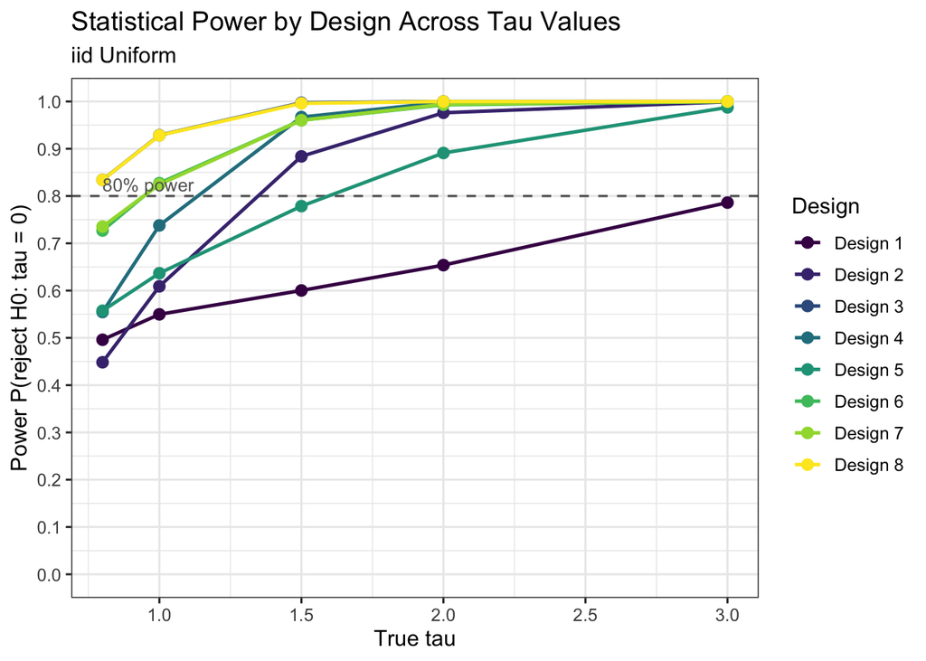

Statistical power by design across tau values (iid Uniform incidence, queen). 80% power reference shown. Designs with lower MSE achieve adequate power at smaller effect sizes.

## 6.3 Rank Trajectories Across Tau Values

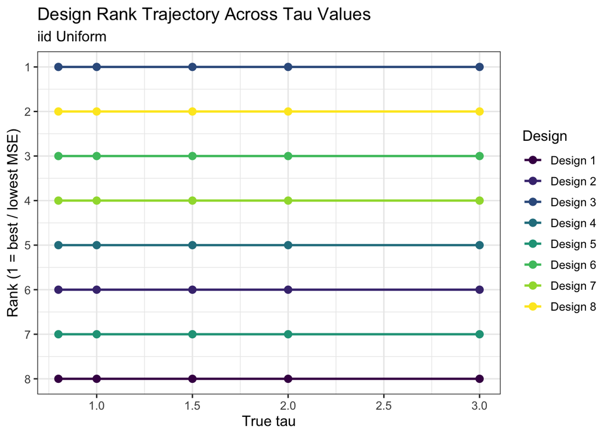

Design rank (1=best MSE) across tau levels (iid Uniform incidence, queen). The tau levels share treatment and noise draws, so stable trajectories show insensitivity to the effect size rather than independent replication.

# 7 Conclusion

Using a Friedman test with Nemenyi post-hoc comparisons and corroborated by pairwise Wilcoxon signed-rank tests, we find (queen contiguity, $\tau = 1.0$, unless stated):

- **23 of 28 design pairs** are significantly different at the $\alpha = 0.05$ level (Nemenyi post-hoc), and **26 of 28** under the Wilcoxon signed-rank test with Holm correction. Under rook (sensitivity), the counts are 21 and 25 of 28.
- **Saturation Quadrants** and **Incidence-Guided Saturation Quadrants** are the recommended designs, forming the top equivalence group with average ranks of 2.10 and 2.35; they are statistically indistinguishable from each other.
- These findings are **robust** across all tested levels of spatial autocorrelation, spillover magnitude, spillover type, neighbor contiguity, and incidence generation mode.

This analysis provides the statistical foundation for recommending specific treatment assignment designs for future spatial CRT studies.

## 8 Appendix: Test Details

## 8.1 Software and Packages

- **R** version 4.5.2
- **PMCMRplus** 1.9.12: Friedman test, Nemenyi post-hoc
- **stats** (base R): Wilcoxon signed-rank test, Holm p-value adjustment
- **Simulation results**: sim_results_MLE_tau_sweep_combined_20260924_025509.rds

## 8.2 Nemenyi P-value Matrix

Full Nemenyi post-hoc p-value matrix (queen, tau = 1.0).

|  | Design 1 | Design 2 | Design 3 | Design 4 | Design 5 | Design 6 | Design 7 | Design 8 |
| --- | --- | --- | --- | --- | --- | --- | --- | --- |
| Design 1 | — | 1.0000 | 0.0000 | 0.0000 | 0.6181 | 0.0000 | 0.0000 | 0.0000 |
| Design 2 | 1.0000 | — | 0.0000 | 0.0000 | 0.5549 | 0.0000 | 0.0000 | 0.0000 |
| Design 3 | 0.0000 | 0.0000 | — | 0.0000 | 0.0000 | 0.0001 | 0.0003 | 0.9849 |
| Design 4 | 0.0000 | 0.0000 | 0.0000 | — | 0.0014 | 0.0000 | 0.0000 | 0.0000 |
| Design 5 | 0.6181 | 0.5549 | 0.0000 | 0.0014 | — | 0.0000 | 0.0000 | 0.0000 |
| Design 6 | 0.0000 | 0.0000 | 0.0001 | 0.0000 | 0.0000 | — | 1.0000 | 0.0058 |
| Design 7 | 0.0000 | 0.0000 | 0.0003 | 0.0000 | 0.0000 | 1.0000 | — | 0.0104 |
| Design 8 | 0.0000 | 0.0000 | 0.9849 | 0.0000 | 0.0000 | 0.0058 | 0.0104 | — |

## 8.3 Wilcoxon P-value Matrix (Holm-adjusted)

Full pairwise Wilcoxon signed-rank p-value matrix (queen, tau = 1.0; Holm-adjusted).

|  | Design 1 | Design 2 | Design 3 | Design 4 | Design 5 | Design 6 | Design 7 | Design 8 |
| --- | --- | --- | --- | --- | --- | --- | --- | --- |
| Design 1 | — | 0.0000 | 0.0000 | 0.0000 | 0.0000 | 0.0000 | 0.0000 | 0.0000 |
| Design 2 | 0.0000 | — | 0.0000 | 0.0000 | 0.0000 | 0.0000 | 0.0000 | 0.0000 |
| Design 3 | 0.0000 | 0.0000 | — | 0.0000 | 0.0000 | 0.0000 | 0.0000 | 0.4130 |
| Design 4 | 0.0000 | 0.0000 | 0.0000 | — | 0.0000 | 0.0000 | 0.0000 | 0.0000 |
| Design 5 | 0.0000 | 0.0000 | 0.0000 | 0.0000 | — | 0.0000 | 0.0000 | 0.0000 |
| Design 6 | 0.0000 | 0.0000 | 0.0000 | 0.0000 | 0.0000 | — | 0.8842 | 0.0000 |
| Design 7 | 0.0000 | 0.0000 | 0.0000 | 0.0000 | 0.0000 | 0.8842 | — | 0.0000 |
| Design 8 | 0.0000 | 0.0000 | 0.4130 | 0.0000 | 0.0000 | 0.0000 | 0.0000 | — |